# Project 3

## Problem 4 - SDSS galaxies with sklearn

The data is provided in the file **"specz_data.txt"**. The columns of the file (length of 13) correspond to -  
spectroscopic redshift ('zspec'), RA, DEC, magnitudes in 5 bands - u, g, r, i, z (denoted as 'mu,' 'mg,' 'mr,' 'mi,' 'mz' respectively); Exponential and de Vaucouleurs model magnitude fits ('logExp' and 'logDev' http://www.sdss.org/dr12/algorithms/magnitudes/); zebra fit ('pz_zebra); Neural Network fit ('pz_NN') and its error estimate ('pz_NN_Err')

We will undertake 2 exercises -

- Regression
  - We will use the magnitude of object in different bands ('mu, mg, mr, mi, mz') and do a regression exercise to estimate the redshift of the object. Hence our feature space is 5.
  - The correct redshift is given by 'zspec', which is the spectroscopic redshift of the object. We will use this for training and testing purpose.

    Sidenote: Photometry vs. Spectroscopy

    *The amount of energy we receive from celestial objects – in the form of radiation – is called the flux, and an astro- nomical technique of measuring the flux is photometry. Flux is usually measured over broad wavelength bands, and with the estimate of the distance to an object, it can infer the object’s luminosity, temperature, size, etc. Usually light is passed through colored filters, and we measure the intensity of the filtered light.*

    On the other hand, spectroscopy deals with the spectrum of the emitted light. This tells us what the object is made of, how it is moving, the pressure of the material in it, etc. Note that for faint objects making photometric observation is much easier.

    Photometric redshift (photoz) is an estimate of the distance to the object using photometry. Spectroscopic redshift observes the object’s spectral lines and measures their shifts due to the Doppler effect to infer the distance.</i>
- Classification
  - We will use the same magnitudes and now also the redshift of the object ('zspec') to classify the object as either Elleptical or Spiral. Hence our feature space is now 6.
  - The correct class is given by compring 'logExp' and 'logDev' which are the fits for Exponential and Devocular profiles. If logExp > logDev, its a spiral and vice-versa. We will use this for training and testing purpose. Since the classes are not explicitly given, generate a column for those (Classes can be $\pm 1$. If it is $0$, it does not belong to either of the class.)

```python
from google.colab import drive
drive.mount('/content/drive')
```

```python
# -*- coding: utf-8 -*-
import numpy as np
#For plotting
import matplotlib.pyplot as plt
%matplotlib inline
import warnings
warnings.filterwarnings('ignore')

seed=12
np.random.seed(seed)
import sklearn
```

##### Cleaning

Read in the files to create the data (X and Y) for both regression and classification.  
You will have to clean the data -

- Drop the entries that are nan or infinite
- Drop the unrealistic numbers such as 999, -999; and magnitudes that are unrealistic. Since these are absolute magnitudes, they should be positive and high. Lets choose a magnitude limit of 15 as safe bet.
- For classification, drop the entries that do not belong to either of the class

```python
#Read in and create data

fname = '/content/drive/My Drive/P188_288/P188_288_Project3/specz_data.txt'
spec_dat=np.genfromtxt(fname,names=True)
print(spec_dat.dtype.fields.keys())
#convenience variable
zspec = spec_dat['zspec']
pzNN = spec_dat['pz_NN']
#some N redshifts are not defined
pzNN[pzNN < 0] = np.nan

#For Regression
bands = ['u', 'g', 'r','i', 'z' ]
mlim = 15

xdata = np.concatenate([[spec_dat['m%s'%i] for i in bands]]).T
bad = (xdata[:, 0] < mlim) | (xdata[:, 1] < mlim) | (xdata[:, 2] < mlim) & (xdata[:, 3] < mlim) | (xdata[:, 4] < mlim)
xdata = xdata[~bad]
xdata[xdata<0] = 0
ydata = zspec[~bad]

#For classification
classes = np.sign(spec_dat['logExp'] - spec_dat['logDev'])
tmp = np.concatenate([[spec_dat['m%s'%i] for i in bands]]).T
xxdata = np.concatenate([tmp, zspec.reshape(-1, 1)], axis=1)
bad = (classes==0) | (xxdata[:, 0] < mlim) | (xxdata[:, 1] < mlim) | (xxdata[:, 2] < mlim) & (xxdata[:, 3] < mlim) | (xxdata[:, 4] < mlim)
xxdata = xxdata[~bad]
classes = classes[~bad]
```

```
dict_keys(['zspec', 'RA', 'DEC', 'mu', 'mg', 'mr', 'mi', 'mz', 'logExp', 'logDev', 'pz_zebra', 'pz_NN', 'pz_NN_Err'])
```

For regression, X and Y data (called "xdata" and "ydata," respectively) is cleaned magnitudes (5 feature space) and spectroscopic redshifts respectively. For classification, X and Y data (called "xxdata" and "classes" respectively) is cleaned magnitudes+spectroscopic redshifts respectively (6 feature space) and classees respectively.

```python
print('For Regression:')
print('Before: Size of datasets is ', zspec.shape[0])
print('After: Size of datasets is ', xdata.shape[0])
print('')
print('For Classification:')
print('Before: Size of datasets is ', zspec.shape[0])
print('After: Size of datasets is ', xxdata.shape[0])
```

```
For Regression:
Before: Size of datasets is  5338
After: Size of datasets is  4535

For Classification:
Before: Size of datasets is  5338
After: Size of datasets is  4147
```

##### Visualization

The next step should be to visualize the data.  
For regression

- Make a histogram for the distribution of the data (spectroscopic redshift).
- Make 5 2D histograms of the distribution of the magnitude as function of redshift (Hint: https://matplotlib.org/devdocs/api/_as_gen/matplotlib.axes.Axes.hist2d.html)

For classification

- Make 6 1-d histogram for the distribution of the data (6 features - zspec and 5 magnitudes) for both class 1 and -1 separately

*1. Make histograms for both regression and classification.*

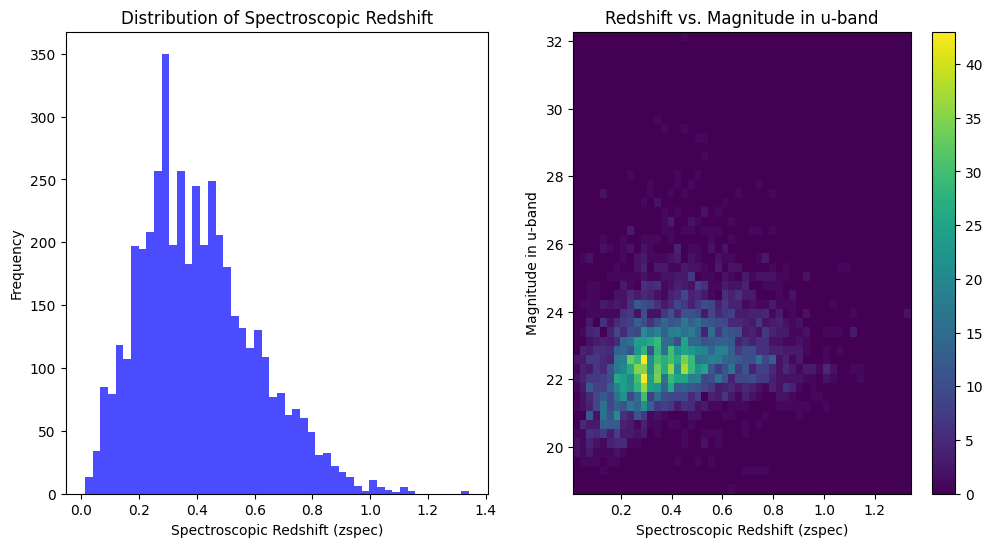

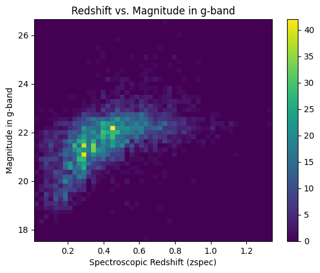

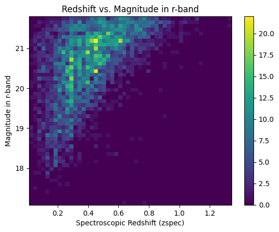

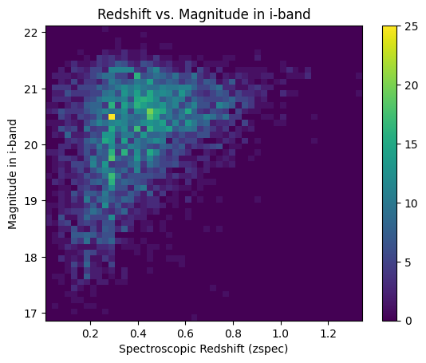

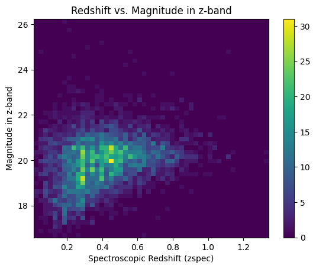

[figure not shown]

```python
plt.figure(figsize=(12, 6))

plt.subplot(1, 2, 1)
plt.hist(ydata, bins=50, color='blue', alpha=0.7)
plt.xlabel('Spectroscopic Redshift (zspec)')
plt.ylabel('Frequency')
plt.title('Distribution of Spectroscopic Redshift')


plt.subplot(1, 2, 2)
for i, band in enumerate(bands):
    plt.hist2d(ydata, xdata[:, i], bins=50, cmap='viridis')
    plt.xlabel('Spectroscopic Redshift (zspec)')
    plt.ylabel(f'Magnitude in {band}-band')
    plt.title(f'Redshift vs. Magnitude in {band}-band')
    plt.colorbar()
    plt.show()


fig, axs = plt.subplots(2, 3, figsize=(18, 10))

for i, feature in enumerate(['zspec'] + bands):
    row = i // 3
    col = i % 3
    axs[row, col].hist(xxdata[classes == 1, i], bins=50, alpha=0.5, label='Class 1', color='green')
    axs[row, col].hist(xxdata[classes == -1, i], bins=50, alpha=0.5, label='Class -1', color='red')
    axs[row, col].set_xlabel(f'{feature} Value')
    axs[row, col].set_ylabel('Frequency')
    axs[row, col].legend()
    axs[row, col].set_title(f'Distribution of {feature}')

plt.tight_layout()
plt.show()
```

*2. Do the following preprocessing:*

##### Preprocessing:

- Next, split the sample into training data and the testing data. We will be using the training data to train different algorithms and then compare the performance over the testing data. In this project, keep 80% data as training data and uses the remaining 20% data for testing.
- Often, the data can be ordered in a specific manner, hence shuffle the data prior to splitting it into training and testing samples.
- Many algorithms are also not scale invariant, and hence scale the data (different features to a uniform scale). All this comes under preprocessing the data. http://scikit-learn.org/stable/modules/preprocessing.html#preprocessing  
  Use StandardScaler from sklearn (or write your own routine) to center the data to 0 mean and 1 variance. Note that you only center the training data and then use its mean and variance to scale the testing data before using it.

Hint: How to get a scaled training data:

1. Let the training data be: train = ("training X data", "training Y data")
2. You can first define a StandardScaler:  
   scale_xdata, scale_ydata = preprocessing.StandardScaler(), preprocessing.StandardScaler()
3. Then, do the fit:  
   for regression: scale_xdata.fit(train_regression[0]), scale_ydata.fit(train_regression[1].reshape(-1, 1))  
   for classication: scale_xdata.fit(train_classification[0])  
   Here, no need to fit for y data for classification (it's either +1 or -1. Already scaled)
4. Next, transform:  
   for regression: scaled_train_data = (scale_xdata.fit_transform(train_regression[0]), scale_ydata.fit_transform(train_regression[1].reshape(-1, 1)))  
   for classication: scaled_train_data = (scale_xdata.fit_transform(train_classification[0]), train_classification[1])  
   Again, y data is already scaled for classification.

Do this for test data as well.

```python
from sklearn import preprocessing
```

```python
from sklearn.model_selection import train_test_split
from sklearn.preprocessing import StandardScaler

seed = 12

x_train_reg, x_test_reg, y_train_reg, y_test_reg = train_test_split(xdata, ydata, test_size=0.2, random_state=seed, shuffle=True)

x_train_class, x_test_class, y_train_class, y_test_class = train_test_split(xxdata, classes, test_size=0.2, random_state=seed, shuffle=True)


scale_xdata = StandardScaler()
scale_ydata = StandardScaler()

scale_xdata.fit(x_train_reg)
scale_ydata.fit(y_train_reg.reshape(-1, 1))
scaled_x_train_reg = scale_xdata.transform(x_train_reg)
scaled_y_train_reg = scale_ydata.transform(y_train_reg.reshape(-1, 1))
scaled_x_test_reg = scale_xdata.transform(x_test_reg)
scaled_y_test_reg = scale_ydata.transform(y_test_reg.reshape(-1, 1))

scale_xdata.fit(x_train_class)
scaled_x_train_class = scale_xdata.transform(x_train_class)
scaled_x_test_class = scale_xdata.transform(x_test_class)

scaled_x_train_reg.shape, scaled_y_train_reg.shape, scaled_x_test_reg.shape, scaled_y_test_reg.shape, scaled_x_train_class.shape, scaled_x_test_class.shape
```

```
((3628, 5), (3628, 1), (907, 5), (907, 1), (3317, 6), (830, 6))
```

##### Metrics

The last remaining preperatory step is to write metric for gauging the performance of the algorithm. Write a function to calculate the 'RMS' error given (y_predict, y_truth) to gauge regression and another function to evaluate accuracy of classification.  
In addition, for classification, we will also use confusion matrix.

Below is an example you can use. Feel free to write you own.

```python
from sklearn.metrics import confusion_matrix

def rms(x, y, scale1=None, scale2=None):
    '''Calculate the rms error given the truth and the prediction
    '''
    mask = np.isfinite(x[:]) & np.isfinite(y[:])
    if scale1 is not None:
        x= scale1.inverse_transform(x)
    if scale2 is not None:
        y = scale2.inverse_transform(y)
    return  np.sqrt(np.mean((x[mask] - y[mask]) ** 2))

def acc(x, y):
    '''Calculate the accuracy given the truth and the prediction
    '''
    mask = np.isfinite(x[:]) & np.isfinite(y[:])
    return  (x == y).sum()/x.size
```

#### Hyperparameter method

Now, we will be varying hyperparameters to get the best model and build some intuition. There are various ways to do this and we will use Grid Search methodology (as you did in Problem 1 and 2) which simply tries all the combinations along with some cross-validation scheme. For most part, we will use 4-fold cross validation.  
Sklearn provides GridSearchCV functionality for this purpose.

Its recommended to spend some time to go through output format of GridSearchCV and write some utility functions to make the recurring plots for every parameter.  
Grid Search returns a dictionary with self explanatory keys for the most part. Mostly, the keys correspond to (masked) numpy arrays of size = #(all possible combination of parameters). The value of individual parameter in every combination is given in arrays with keys starting from 'param_*' and this should help you to match the combination with the corresponding scores.  
For masked arrays, you can access the data values by using *.data  
*Do not overwrite these grid search-ed variables (and not only their result) since we will compare all the models together in the end*

```python
from sklearn.model_selection import GridSearchCV, RandomizedSearchCV
# http://scikit-learn.org/stable/modules/generated/sklearn.model_selection.GridSearchCV.html
# http://scikit-learn.org/stable/modules/generated/sklearn.model_selection.RandomizedSearchCV.html
```

*You can choose to do only one of the two classifiers: kNN or Random Forests.*  
*If you choose to do Method 2 (Random Forests), take a look at hints from Method 1 (kNN).*

### Option (1)

### Method 1. k Nearest Neighbors

For regression, let us play with grid search using knn to tune hyperparmeters. (https://scikit-learn.org/stable/modules/generated/sklearn.neighbors.KNeighborsRegressor.html) Consider the following 3 hyperparameters -

- Number of neighbors ([2, 3, 5, 10, 15, 20, 25, 50, 100])
- Weights of leaves (Uniform or Inverse Distance weighing)
- Distance metric (Eucledian or Manhattan distance - parameter 'p')

*1. Do a grid search on these parameters. List the combination of hyperparameters you tried and evaluate the accuracy (mean test score) and its standard deviation. Which gives the highest accuracy value?*

```python
from sklearn.neighbors import KNeighborsRegressor
```

Hint: (Read the documentations carefully for more detail.)

First, define the hyperparameters: parameters = {'n_neighbors':[2, 3, 5, 10, 15, 20, 25, 50, 100], 'weights':['uniform', 'distance'], 'p':[1, 2]}

Specify the algorithm you want to use: e.g. knnr = KNeighborsRegressor()

Then, Do a grid search on these parameters using 4 fold cross validation: gcknn = GridSearchCV(knnr, parameters, cv=4)

Do the fit: gcknn.fit(*scaled_training_data)

(Let "scaled_training_data" be the training data where "scaled_training_data = ("train X data", "train Y data")"

Get results: $results = gcknn.cv_results_$

$cv_results_$ has the following dictionaries: "rank_test_score," "mean_test_score," "std_test_score," and "params" (See http://scikit-learn.org/stable/modules/generated/sklearn.model_selection.GridSearchCV.html)

Then, you can evaluate the models based on "rank_test_score" and print out their "params," along with their "mean_test_score" and "std_test_score".

```python
def rms(x, y, scale1=None, scale2=None):
    '''Calculate the RMS error given the truth and the prediction'''
    mask = np.isfinite(x[:]) & np.isfinite(y[:])
    if scale1 is not None:
        x = scale1.inverse_transform(x)
    if scale2 is not None:
        y = scale2.inverse_transform(y)
    return np.sqrt(np.mean((x[mask] - y[mask]) ** 2))

def acc(x, y):
    '''Calculate the accuracy given the truth and the prediction'''
    mask = np.isfinite(x[:]) & np.isfinite(y[:])
    return (x == y).sum() / x.size
parameters = {
    'n_neighbors': [2, 3, 5, 10, 15, 20, 25, 50, 100],
    'weights': ['uniform', 'distance'],
    'p': [1, 2]  # 1: Manhattan, 2: Euclidean
}

knnr = KNeighborsRegressor()

gcknn = GridSearchCV(knnr, parameters, cv=4)
gcknn.fit(scaled_x_train_reg, scaled_y_train_reg.ravel())
results = gcknn.cv_results_
sorted_results = sorted(zip(results['mean_test_score'], results['std_test_score'], results['params']),
                        key=lambda x: -x[0])

for mean_score, std_score, params in sorted_results:
    print(f"Mean Test Score: {mean_score:.4f}, Std Dev: {std_score:.4f}, Parameters: {params}")
```

```
Mean Test Score: 0.5523, Std Dev: 0.0255, Parameters: {'n_neighbors': 20, 'p': 1, 'weights': 'distance'}
Mean Test Score: 0.5520, Std Dev: 0.0255, Parameters: {'n_neighbors': 25, 'p': 1, 'weights': 'distance'}
Mean Test Score: 0.5506, Std Dev: 0.0236, Parameters: {'n_neighbors': 15, 'p': 1, 'weights': 'distance'}
Mean Test Score: 0.5499, Std Dev: 0.0264, Parameters: {'n_neighbors': 20, 'p': 2, 'weights': 'distance'}
Mean Test Score: 0.5481, Std Dev: 0.0242, Parameters: {'n_neighbors': 15, 'p': 2, 'weights': 'distance'}
Mean Test Score: 0.5454, Std Dev: 0.0277, Parameters: {'n_neighbors': 25, 'p': 2, 'weights': 'distance'}
Mean Test Score: 0.5425, Std Dev: 0.0210, Parameters: {'n_neighbors': 10, 'p': 2, 'weights': 'distance'}
Mean Test Score: 0.5407, Std Dev: 0.0227, Parameters: {'n_neighbors': 10, 'p': 1, 'weights': 'distance'}
Mean Test Score: 0.5372, Std Dev: 0.0278, Parameters: {'n_neighbors': 50, 'p': 1, 'weights': 'distance'}
Mean Test Score: 0.5332, Std Dev: 0.0284, Parameters: {'n_neighbors': 50, 'p': 2, 'weights': 'distance'}
Mean Test Score: 0.5186, Std Dev: 0.0274, Parameters: {'n_neighbors': 100, 'p': 1, 'weights': 'distance'}
Mean Test Score: 0.5174, Std Dev: 0.0251, Parameters: {'n_neighbors': 15, 'p': 1, 'weights': 'uniform'}
Mean Test Score: 0.5159, Std Dev: 0.0238, Parameters: {'n_neighbors': 10, 'p': 2, 'weights': 'uniform'}
Mean Test Score: 0.5150, Std Dev: 0.0266, Parameters: {'n_neighbors': 20, 'p': 1, 'weights': 'uniform'}
Mean Test Score: 0.5146, Std Dev: 0.0270, Parameters: {'n_neighbors': 15, 'p': 2, 'weights': 'uniform'}
Mean Test Score: 0.5128, Std Dev: 0.0296, Parameters: {'n_neighbors': 100, 'p': 2, 'weights': 'distance'}
Mean Test Score: 0.5126, Std Dev: 0.0290, Parameters: {'n_neighbors': 20, 'p': 2, 'weights': 'uniform'}
Mean Test Score: 0.5112, Std Dev: 0.0263, Parameters: {'n_neighbors': 10, 'p': 1, 'weights': 'uniform'}
Mean Test Score: 0.5098, Std Dev: 0.0269, Parameters: {'n_neighbors': 25, 'p': 1, 'weights': 'uniform'}
Mean Test Score: 0.5075, Std Dev: 0.0208, Parameters: {'n_neighbors': 5, 'p': 1, 'weights': 'distance'}
Mean Test Score: 0.5038, Std Dev: 0.0291, Parameters: {'n_neighbors': 25, 'p': 2, 'weights': 'uniform'}
Mean Test Score: 0.5024, Std Dev: 0.0203, Parameters: {'n_neighbors': 5, 'p': 2, 'weights': 'distance'}
Mean Test Score: 0.4870, Std Dev: 0.0203, Parameters: {'n_neighbors': 5, 'p': 1, 'weights': 'uniform'}
Mean Test Score: 0.4855, Std Dev: 0.0287, Parameters: {'n_neighbors': 50, 'p': 1, 'weights': 'uniform'}
Mean Test Score: 0.4802, Std Dev: 0.0287, Parameters: {'n_neighbors': 50, 'p': 2, 'weights': 'uniform'}
Mean Test Score: 0.4799, Std Dev: 0.0199, Parameters: {'n_neighbors': 5, 'p': 2, 'weights': 'uniform'}
Mean Test Score: 0.4595, Std Dev: 0.0268, Parameters: {'n_neighbors': 100, 'p': 1, 'weights': 'uniform'}
Mean Test Score: 0.4528, Std Dev: 0.0290, Parameters: {'n_neighbors': 100, 'p': 2, 'weights': 'uniform'}
Mean Test Score: 0.4484, Std Dev: 0.0227, Parameters: {'n_neighbors': 3, 'p': 1, 'weights': 'distance'}
Mean Test Score: 0.4476, Std Dev: 0.0311, Parameters: {'n_neighbors': 3, 'p': 2, 'weights': 'distance'}
Mean Test Score: 0.4321, Std Dev: 0.0220, Parameters: {'n_neighbors': 3, 'p': 1, 'weights': 'uniform'}
Mean Test Score: 0.4301, Std Dev: 0.0296, Parameters: {'n_neighbors': 3, 'p': 2, 'weights': 'uniform'}
Mean Test Score: 0.3854, Std Dev: 0.0445, Parameters: {'n_neighbors': 2, 'p': 2, 'weights': 'distance'}
Mean Test Score: 0.3838, Std Dev: 0.0472, Parameters: {'n_neighbors': 2, 'p': 1, 'weights': 'distance'}
Mean Test Score: 0.3776, Std Dev: 0.0443, Parameters: {'n_neighbors': 2, 'p': 1, 'weights': 'uniform'}
Mean Test Score: 0.3739, Std Dev: 0.0413, Parameters: {'n_neighbors': 2, 'p': 2, 'weights': 'uniform'}
```

*2. Also print out fitting and scoring times for all hyperparameter combinations.*

Hint: Assume that you got results from: $results = gcknn.cv_results_$

Then, get the scoring time: results['mean_score_time']

and the fitting time: results['mean_fit_time']

```python
import pandas as pd

fit_times = results['mean_fit_time']
score_times = results['mean_score_time']

timing_data = pd.DataFrame({
    'Parameters': [param['n_neighbors'] for param in results['params']],
    'Weighting': [param['weights'] for param in results['params']],
    'Distance Metric': ['Manhattan' if param['p'] == 1 else 'Euclidean' for param in results['params']],
    'Mean Fit Time': fit_times,
    'Mean Score Time': score_times
})

timing_data.head()
```

|  | Parameters | Weighting | Distance Metric | Mean Fit Time | Mean Score Time |
| --- | --- | --- | --- | --- | --- |
| 0 | 2 | uniform | Manhattan | 0.003715 | 0.014857 |
| 1 | 2 | distance | Manhattan | 0.003472 | 0.015558 |
| 2 | 2 | uniform | Euclidean | 0.003449 | 0.011358 |
| 3 | 2 | distance | Euclidean | 0.003394 | 0.009294 |
| 4 | 3 | uniform | Manhattan | 0.003553 | 0.019270 |

*3. Based on the results you obtained in Part 1 and 2, answer the following questions*

- Is it always better to use more neighbors?
- Is it better to weigh the leaves, if yes, which distnace metric performs better?
- GridCV returns fitting and scoring time for every combination. You will find that scoring time is higher than training time. Why do you think is that the case?

##### Answer:It is not always better to use more neighbors

In the knn model, weighing the leaves have better performance. The Manhattan distance performed better than Euclidean distance. it happens at this case because scoring phase involves calculating the distance of a test sample to all training samples, sorting these distances to find the nearest neighbors, and then making predictions based on these neighbors. This process is computationally more intensive than the training phase

*4. Which parameters seem to affect the performance most? To better answer this question, make plots of the mean test score for each hyperparameter.*

Hint: Suppose you have two types of hyperparameters: A and B. Let A = [1, 2] and B = [1, 2, 4, 7, 10].

Let A = 1. Then, you can try (A,B) = (1,1), (1,2), (1,4), (1,7), (1,10) Suppose that the mean score you got for the above combination is [0.7, 0.72, 0.75, 0.77, 0.8]. Similarly, for A = 2, you tried (A,B) = (2,1), (2,2), (2,4), (2,7), (2,10) and obtaind the mean score of [0.8, 0.82, 0.85, 0.87, 0.9].

To better see how changing the value of paramter A affects the performance, you can make the following plot:

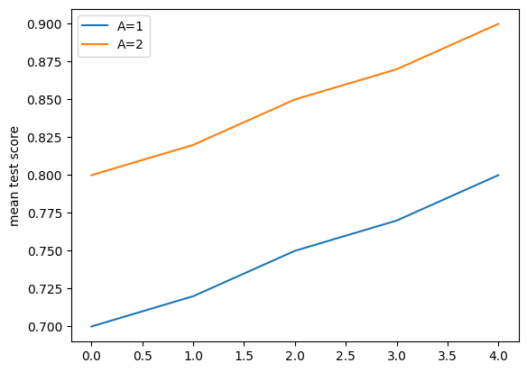

```python
A_1 = [0.7, 0.72, 0.75, 0.77, 0.8]
A_2 = [0.8, 0.82, 0.85, 0.87, 0.9]

plt.plot(A_1, label = "A=1")
plt.plot(A_2, label = "A=2")
plt.ylabel("mean test score")
plt.legend()
plt.show()
```

This is the plot of the mean test score for A marginalizing over B.

Similarly, make a plot of the mean test score for each kNN hyperparameter.

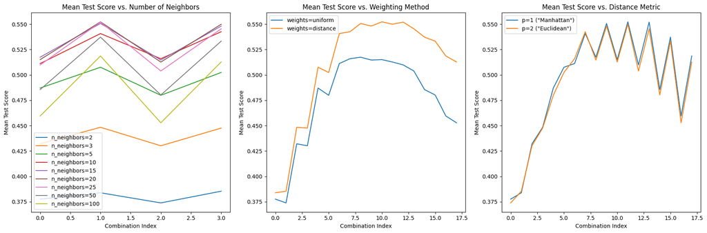

```python
mean_scores = results['mean_test_score']

data_by_neighbors = {n: [] for n in parameters['n_neighbors']}
data_by_weights = {'uniform': [], 'distance': []}
data_by_p = {1: [], 2: []}

for mean_score, params in zip(mean_scores, results['params']):
    data_by_neighbors[params['n_neighbors']].append(mean_score)
    data_by_weights[params['weights']].append(mean_score)
    data_by_p[params['p']].append(mean_score)

plt.figure(figsize=(18, 6))

plt.subplot(1, 3, 1)
for n in data_by_neighbors:
    plt.plot(data_by_neighbors[n], label=f'n_neighbors={n}')
plt.title('Mean Test Score vs. Number of Neighbors')
plt.xlabel('Combination Index')
plt.ylabel('Mean Test Score')
plt.legend()

plt.subplot(1, 3, 2)
for weight in data_by_weights:
    plt.plot(data_by_weights[weight], label=f'weights={weight}')
plt.title('Mean Test Score vs. Weighting Method')
plt.xlabel('Combination Index')
plt.ylabel('Mean Test Score')
plt.legend()

plt.subplot(1, 3, 3)
for p in data_by_p:
    plt.plot(data_by_p[p], label=f'p={p} ("{"Manhattan" if p == 1 else "Euclidean"}")')
plt.title('Mean Test Score vs. Distance Metric')
plt.xlabel('Combination Index')
plt.ylabel('Mean Test Score')
plt.legend()

plt.tight_layout()
plt.show()
```

*5. You have determined the best combination of hyperparameters and CV schemes. Predict the test y data using the GridSearchCV method. Use the "rms" metric function we defined earlier and calculate the rms error on the test data.*

Hint: To determine the rms error, you need:

Truth: given from data (test_data[1])  
Prediction: gridsearch.predict(test_data[0]) (https://scikit-learn.org/stable/modules/generated/sklearn.model_selection.GridSearchCV.html)

```python
y_pred_reg = gcknn.predict(scaled_x_test_reg)
y_pred_reg_adjusted = y_pred_reg.reshape(-1, 1)
rms_error_corrected = rms(y_pred_reg_adjusted, scaled_y_test_reg, scale2=scale_ydata)
rms_error_corrected
```

```
0.7471320869796167
```